# 01. Xenium Preprocessing and QC

Andrew Portuguese

June 07, 2026

# 1 Proseg segmentation source

Proseg is the primary segmentation source for this analysis. The original Xenium output folders are retained as morphology and raw-data references, but the cell count matrices, centroids, and QC metrics below come from completed Proseg outputs.

```r
proseg_bin <- file.path(project_base, ".tools", "proseg", "bin", "proseg")
proseg_runner <- file.path(analysis_dir, "run_proseg_xenium.sh")

proseg_status <- data.frame(
  item = c("proseg binary", "proseg runner"),
  path = c(proseg_bin, proseg_runner),
  available = c(file.exists(proseg_bin), file.exists(proseg_runner)),
  stringsAsFactors = FALSE
)
if (file.exists(proseg_bin)) {
  proseg_status$version <- c(
    paste(system2(proseg_bin, "--version", stdout = TRUE), collapse = " "),
    NA_character_
  )
} else {
  proseg_status$version <- NA_character_
}

knitr::kable(proseg_status, row.names = FALSE, caption = "Project-local Proseg installation status")
```

Project-local Proseg installation status

| item | path | available | version |
| --- | --- | --- | --- |
| proseg binary | .tools/proseg/bin/proseg | FALSE | NA |
| proseg runner | Analysis/run_proseg_xenium.sh | TRUE | NA |

```r
proseg_validation_summary <- do.call(rbind, lapply(c("EBV_POS", "EBV_NEG"), validate_proseg_output))
proseg_validation_summary$assigned_fraction <- round(proseg_validation_summary$assigned_fraction, 4)
knitr::kable(proseg_validation_summary, row.names = FALSE, caption = "Completed Proseg output validation")
```

Completed Proseg output validation

| sample_key | n_cells | n_genes | counts_nrow | counts_ncol | counts_nnz | counts_sum | total_transcripts | expected_assigned_count | assigned_fraction | duplicated_original_cell_ids | median_cell_volume | max_cell_volume |
| --- | --- | --- | --- | --- | --- | --- | --- | --- | --- | --- | --- | --- |
| EBV_POS | 379543 | 480 | 379543 | 480 | 25254921 | 89482796 | 90627118 | 89445079 | 0.9870 | 0 | 24.0 | 1419.50 |
| EBV_NEG | 237634 | 480 | 237634 | 480 | 16688140 | 53072136 | 54068904 | 53035735 | 0.9809 | 0 | 32.5 | 614.25 |

# 2 Read Proseg-backed Xenium data (EBV_POS + EBV_NEG)

Here the completed Proseg count matrices and cell metadata are loaded into Seurat objects. Cell identifiers use Proseg `original_cell_id`, and Proseg centroids are stored in metadata for downstream core mapping and spatial QC.

```r
xenium_pos <- get_cached_rds(
  file.path(cache_root, "xenium_pos_raw_proseg.rds"),
  function() load_proseg_seurat_object("EBV_POS"),
  refresh = refresh_raw,
  expected_version = make_cache_tag(segmentation_cache_tag, "raw", "proseg", "EBV_POS"),
  allow_legacy = FALSE,
  metadata = list(sample_key = "EBV_POS", segmentation_source = segmentation_source)
)
```

```
## Using cache: xenium_pos_raw_proseg.rds
```

```r
xenium_neg <- get_cached_rds(
  file.path(cache_root, "xenium_neg_raw_proseg.rds"),
  function() load_proseg_seurat_object("EBV_NEG"),
  refresh = refresh_raw,
  expected_version = make_cache_tag(segmentation_cache_tag, "raw", "proseg", "EBV_NEG"),
  allow_legacy = FALSE,
  metadata = list(sample_key = "EBV_NEG", segmentation_source = segmentation_source)
)
```

```
## Using cache: xenium_neg_raw_proseg.rds
```

```r
xenium_raw <- list(EBV_POS = xenium_pos, EBV_NEG = xenium_neg)
```

## 2.1 2.5-style preprocessing in Seurat (EBV_POS + EBV_NEG)

This chunk implements a Seurat-only preprocessing workflow analogous to the tutorial-style 2.5 preprocessing step. Cells are filtered by transcript count, normalized, reduced with PCA, embedded with UMAP, and clustered so each TMA has a clean per-sample object for downstream annotation and comparison.

```r
  qc_lower_cutoffs <- c(EBV_POS = 20, EBV_NEG = 20)
  qc_upper_quantile <- 0.98
  preprocessing_dims <- 1:30
  cluster_resolution <- 0.4
  preprocess_in_parallel <- FALSE
  preprocess_apply <- if (isTRUE(preprocess_in_parallel)) maybe_future_lapply else lapply
  preprocessed_stage <- if (!isTRUE(refresh_preprocess) && file.exists(stage_cache_file("preprocessed"))) {
    load_xenium_stage("preprocessed", required = FALSE)
  } else {
    NULL
  }
  use_preprocessed_stage <- is.list(preprocessed_stage) &&
    all(c("xenium_pos", "xenium_neg", "qc_summary") %in% names(preprocessed_stage)) &&
    identical(preprocessed_stage$segmentation_source, segmentation_source) &&
    identical(preprocessed_stage$qc_lower_cutoffs, qc_lower_cutoffs) &&
    identical(preprocessed_stage$qc_upper_quantile, qc_upper_quantile) &&
    identical(preprocessed_stage$preprocessing_dims, preprocessing_dims) &&
    identical(preprocessed_stage$cluster_resolution, cluster_resolution)

  preprocess_xenium <- function(obj,
                                sample_key,
                                lower_cutoff = 20,
                                upper_quantile = 0.98,
                                dims = 1:30,
                                resolution = 0.4) {
    assay <- DefaultAssay(obj)
    counts <- GetAssayData(obj, assay = assay, layer = "counts")
    ncount_col <- paste0("nCount_", assay)
    nfeature_col <- paste0("nFeature_", assay)
    obj[[ncount_col]] <- Matrix::colSums(counts)
    obj[[nfeature_col]] <- Matrix::colSums(counts > 0)

    ncounts <- obj[[ncount_col]][, 1]
    upper_cutoff <- as.numeric(stats::quantile(ncounts, probs = upper_quantile, na.rm = TRUE))
    keep_cells <- Cells(obj)[ncounts >= lower_cutoff & ncounts <= upper_cutoff]
    obj <- subset(obj, cells = keep_cells)

    obj$sample_key <- sample_key
    obj$condition <- gsub("_", " ", sample_key)
    obj$segmentation_source <- segmentation_source

    scale_factor <- stats::median(obj[[ncount_col]][, 1])
    obj <- NormalizeData(obj, scale.factor = scale_factor, verbose = FALSE)

    n_variable_features <- min(2000, nrow(obj))
    obj <- FindVariableFeatures(obj, nfeatures = n_variable_features, verbose = FALSE)
    obj <- ScaleData(obj, features = VariableFeatures(obj), verbose = FALSE)
    obj <- RunPCA(obj, features = VariableFeatures(obj), verbose = FALSE)

    pca_n <- ncol(Embeddings(obj, "pca"))
    dims_use <- dims[dims <= pca_n]
    if (length(dims_use) == 0) stop("No valid PCA dims available for UMAP/clustering.")

    obj <- RunUMAP(obj, dims = dims_use, verbose = FALSE)
    obj <- FindNeighbors(obj, dims = dims_use, verbose = FALSE)
    obj <- FindClusters(obj, resolution = resolution, verbose = FALSE)

    list(
      object = obj,
      qc = data.frame(
        sample = sample_key,
        lower_cutoff = lower_cutoff,
        upper_cutoff = upper_cutoff,
        cells_before = length(ncounts),
        cells_after = length(keep_cells),
        median_ncount = scale_factor,
        segmentation_source = segmentation_source,
        stringsAsFactors = FALSE
      )
    )
  }

  if (isTRUE(use_preprocessed_stage)) {
    message("Using preprocessed stage cache: ", basename(stage_cache_file("preprocessed")))
    xenium_pos <- preprocessed_stage$xenium_pos
    xenium_neg <- preprocessed_stage$xenium_neg
    qc_summary <- preprocessed_stage$qc_summary
  } else {
    preprocessing_results <- setNames(
      preprocess_apply(
        names(xenium_raw),
        function(sample_key) {
          worker_thread_initializer()
          get_cached_rds(
            file.path(cache_root, paste0("preprocessed_", sample_key, ".rds")),
            function() benchmark_stage(
              paste0("preprocessing_", sample_key),
              preprocess_xenium(
                obj = xenium_raw[[sample_key]],
                sample_key = sample_key,
                lower_cutoff = qc_lower_cutoffs[[sample_key]],
                upper_quantile = qc_upper_quantile,
                dims = preprocessing_dims,
                resolution = cluster_resolution
              ),
              extra = list(sample_key = sample_key)
            ),
            refresh = refresh_preprocess,
            expected_version = make_cache_tag(
              "preprocess",
              segmentation_cache_tag,
              sample_key,
              paste0("lower", qc_lower_cutoffs[[sample_key]]),
              paste0("uq", qc_upper_quantile),
              paste0("dims", max(preprocessing_dims)),
              paste0("res", cluster_resolution)
            ),
            allow_legacy = FALSE,
            metadata = list(
              sample_key = sample_key,
              segmentation_source = segmentation_source,
              lower_cutoff = qc_lower_cutoffs[[sample_key]],
              upper_quantile = qc_upper_quantile,
              dims = max(preprocessing_dims),
              resolution = cluster_resolution
            )
          )
        }
      ),
      names(xenium_raw)
    )

    xenium_list <- lapply(preprocessing_results, `[[`, "object")
    qc_summary <- do.call(rbind, lapply(preprocessing_results, `[[`, "qc"))

    xenium_pos <- xenium_list$EBV_POS
    xenium_neg <- xenium_list$EBV_NEG
  }
```

```
## Using preprocessed stage cache: xenium_stage_preprocessed_20260328_layered_cache_v1_proseg_primary_v1_lean_stage_v2.rds
```

```r
  qc_summary
```

```
##          sample lower_cutoff upper_cutoff cells_before cells_after
## EBV_POS EBV_POS           20          798       379543      350764
## EBV_NEG EBV_NEG           20          754       237634      217398
##         median_ncount segmentation_source
## EBV_POS           189              proseg
## EBV_NEG           184              proseg
```

## 2.2 Transcript count histograms before filtering (EBV_POS + EBV_NEG)

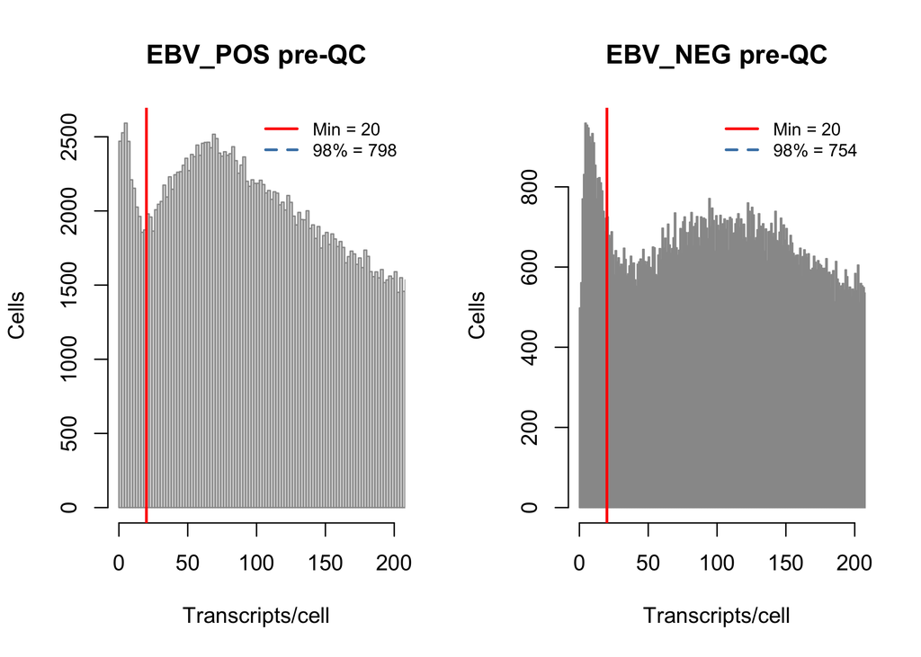

```r
  plot_transcript_hist <- function(obj, sample_key, lower_cutoff, upper_cutoff) {
    assay <- DefaultAssay(obj)
    ncount_col <- paste0("nCount_", assay)
    if (ncount_col %in% colnames(obj@meta.data)) {
      ncounts <- obj[[ncount_col]][, 1]
    } else {
      ncounts <- Matrix::colSums(GetAssayData(obj, assay = assay, layer = "counts"))
    }

    hist(
      ncounts,
      xlim = c(0, 200),
      breaks = 5000,
      main = paste(sample_key, "pre-QC"),
      xlab = "Transcripts/cell",
      ylab = "Cells",
      col = "grey85",
      border = "grey60"
    )
    abline(v = lower_cutoff, col = "red", lwd = 2)
    abline(v = upper_cutoff, col = "steelblue", lwd = 2, lty = 2)
    legend(
      "topright",
      legend = c(
        paste0("Min = ", lower_cutoff),
        paste0("98% = ", round(upper_cutoff))
      ),
      col = c("red", "steelblue"),
      lty = c(1, 2),
      lwd = 2,
      cex = 0.8,
      bty = "n"
    )
  }

  par(mfrow = c(1, 2))
  for (sample_key in names(xenium_raw)) {
    qc_row <- qc_summary[qc_summary$sample == sample_key, , drop = FALSE]
    plot_transcript_hist(
      obj = xenium_raw[[sample_key]],
      sample_key = sample_key,
      lower_cutoff = qc_row$lower_cutoff,
      upper_cutoff = qc_row$upper_cutoff
    )
  }
  par(mfrow = c(1, 1))
```

## 2.3 QC distributions after filtering (EBV_POS + EBV_NEG)

This section checks the filtered objects using simple feature-count and transcript-count summaries. The purpose is to confirm that obvious low-quality cells were removed without collapsing the expected dynamic range of the retained data.

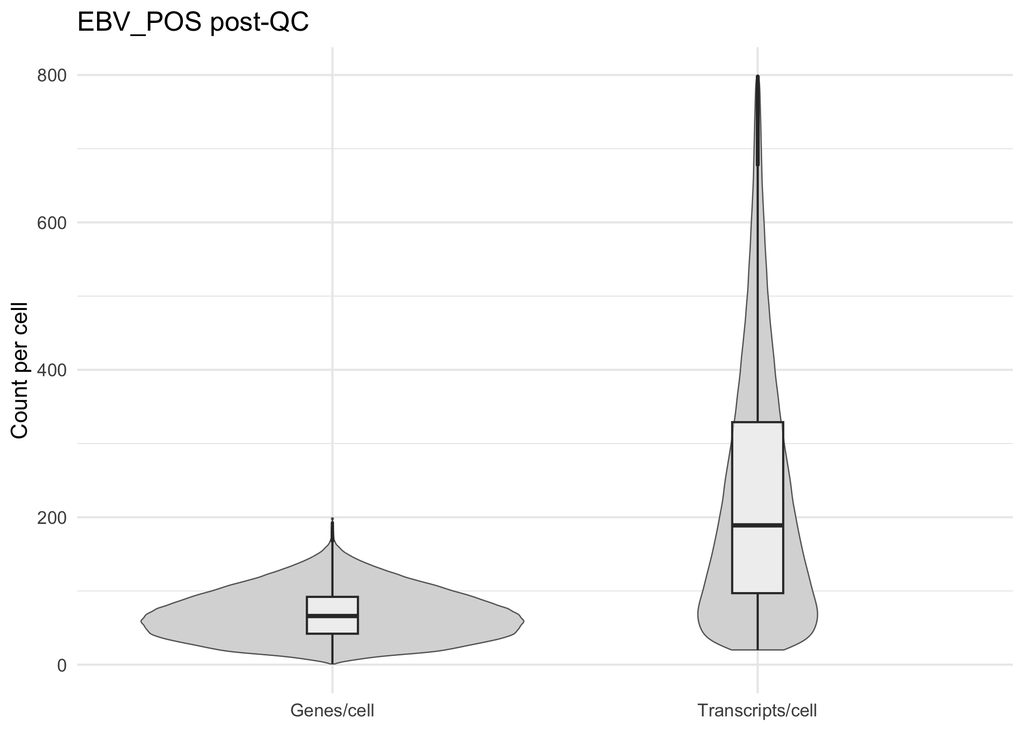

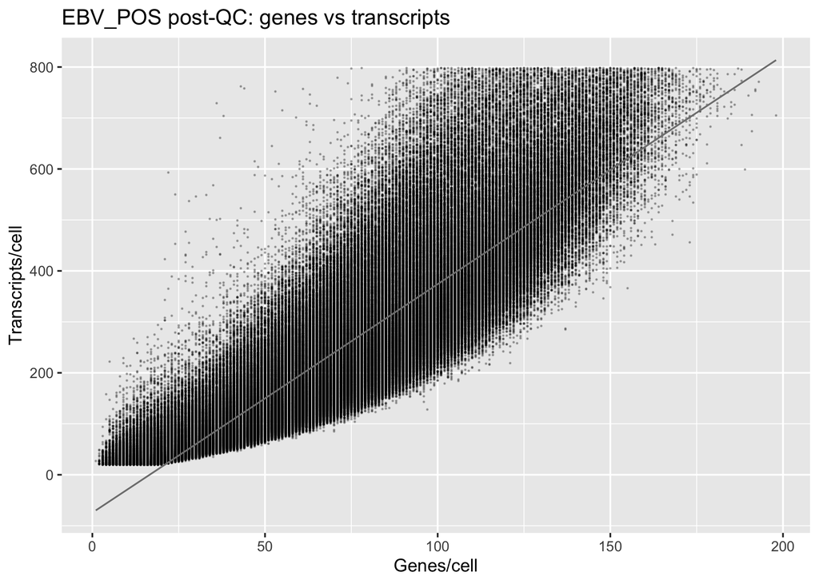

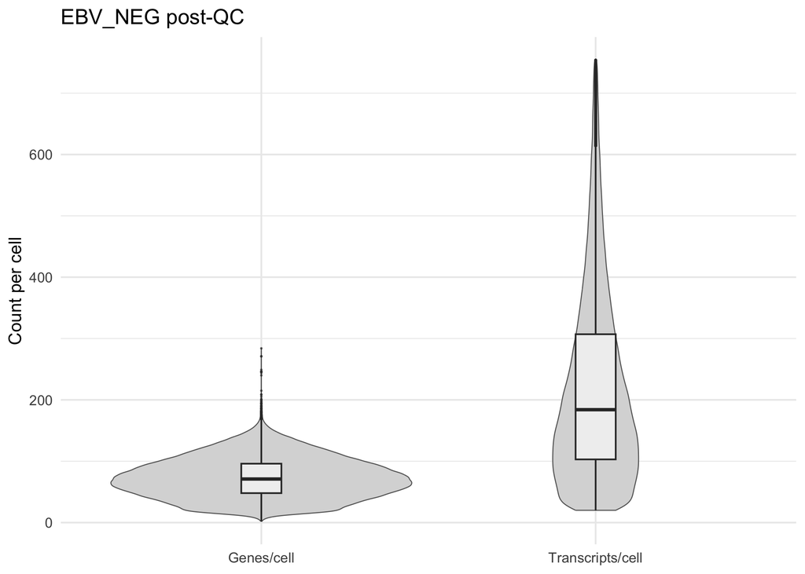

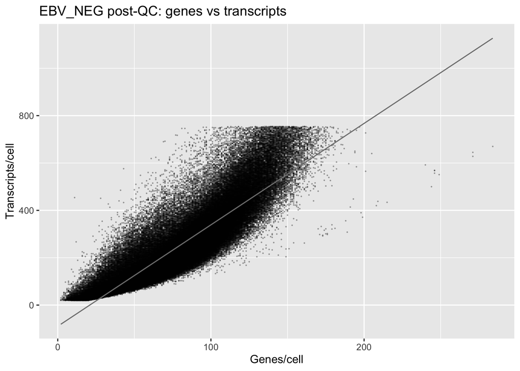

```r
  plot_qc <- function(obj, label) {
    assay <- DefaultAssay(obj)
    nf_col <- paste0("nFeature_", assay)
    nc_col <- paste0("nCount_", assay)

    qc_df <- data.frame(
      nFeature = as.numeric(obj[[nf_col]][, 1]),
      nCount = as.numeric(obj[[nc_col]][, 1]),
      stringsAsFactors = FALSE
    )
    qc_long <- rbind(
      data.frame(
        metric = "Genes/cell",
        value = qc_df$nFeature,
        stringsAsFactors = FALSE
      ),
      data.frame(
        metric = "Transcripts/cell",
        value = qc_df$nCount,
        stringsAsFactors = FALSE
      )
    )
    qc_long$metric <- factor(qc_long$metric, levels = unique(qc_long$metric))

    p1 <- ggplot(qc_long, aes(x = metric, y = value)) +
      geom_violin(fill = "grey85", color = "grey40", linewidth = 0.3) +
      geom_boxplot(width = 0.12, outlier.size = 0.1, alpha = 0.6) +
      scale_y_continuous(labels = scales::comma) +
      labs(
        title = paste(label, "post-QC"),
        x = NULL,
        y = "Count per cell"
      ) +
      theme_minimal(base_size = 11)
    p2 <- ggplot(qc_df, aes(x = nFeature, y = nCount)) +
      geom_point(size = 0.1, alpha = 0.25) +
      geom_smooth(method = "lm", se = FALSE, color = "grey50", linewidth = 0.5) +
      scale_x_continuous(labels = scales::comma) +
      scale_y_continuous(labels = scales::comma) +
      labs(
        title = paste(label, "post-QC: genes vs transcripts"),
        x = "Genes/cell",
        y = "Transcripts/cell"
      )

    print(p1)
    print(p2)
  }

  plot_qc(xenium_pos, "EBV_POS")
  plot_qc(xenium_neg, "EBV_NEG")
```